# clean code

- Done by: [Ismail Ouahbi](https://www.linkedin.com/in/ismail-ouahbi-071145207/) 29/06/22

### Introduction

Predicting an outcome using machine learning models differs based on the `nature` of this outcome. Whether it is `categorical` or `numerical`, further improvements to the dataset are required including `cleaning`, `engineering features`and ensure `data quality`. [Ismail Ouahbi](https://www.linkedin.com/in/ismail-ouahbi-071145207/)

### ML workflow

1. Look at the big picture.
2. Get the data.
3. Discover and visualize the data to gain insights.
4. Prepare the data for Machine Learning algorithms.
5. Select a model and train it.
6. Fine-tune your model.
7. Present your solution.
8. Launch, monitor, and maintain your system.

### Data Description

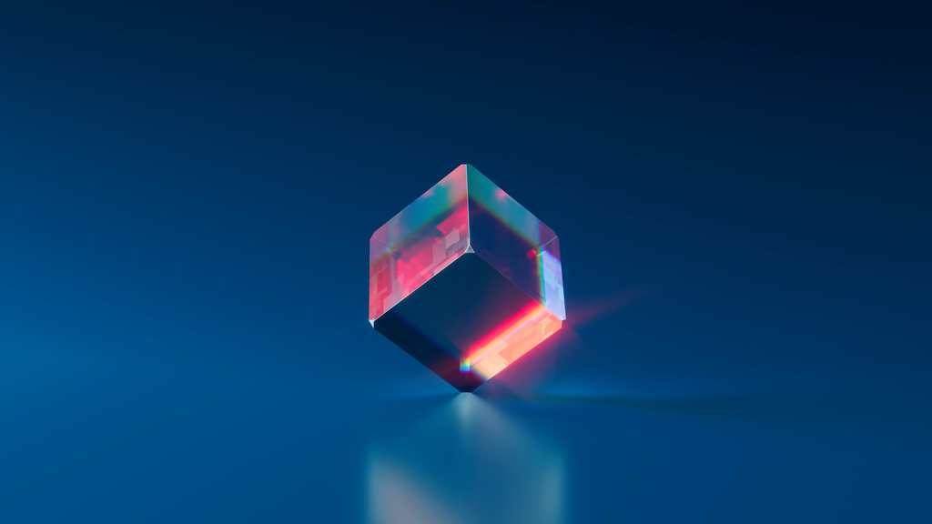

**Diamonds price** prediction using **Machine Learning Regression Models**, The data is composed of `10 variables`:

- **price** price in US dollars (\$326--\$18,823)
- **carat** weight of the diamond (0.2--5.01)
- **cut** quality of the cut (Fair, Good, Very Good, Premium, Ideal)
- **color** diamond colour, from J (worst) to D (best)
- **clarity** a measurement of how clear the diamond is (I1 (worst), SI2, SI1, VS2, VS1, VVS2, VVS1, IF (best))
- **x** length in mm (0--10.74)
- **y** width in mm (0--58.9)
- **z** depth in mm (0--31.8)
- **depth** total depth percentage = z / mean(x, y) = 2 * z / (x + y) (43--79)
- **table** width of top of diamond relative to widest point (43--95)
- Our target variable is the `price`, which is a `numerical` outcome.
- We are going to use `regression algorithms` (`Linear` Reg,`Lasso` Reg & `Ridge` Reg,) in order to predict this numerical outcome
- import packages

```python
import pandas as pd
import numpy as np
import matplotlib.pyplot as plt
import seaborn as sns

#set seaborn style as default style
sns.set()
```

```python
# load the dataset
path = '../data/diamonds.csv'
data = pd.read_csv(path)
```

##### EDA part

```python
# overview about data
data.head()
```

|  | Unnamed: 0 | carat | cut | color | clarity | depth | table | price | x | y | z |
| --- | --- | --- | --- | --- | --- | --- | --- | --- | --- | --- | --- |
| 0 | 1 | 0.23 | Ideal | E | SI2 | 61.5 | 55.0 | 326 | 3.95 | 3.98 | 2.43 |
| 1 | 2 | 0.21 | Premium | E | SI1 | 59.8 | 61.0 | 326 | 3.89 | 3.84 | 2.31 |
| 2 | 3 | 0.23 | Good | E | VS1 | 56.9 | 65.0 | 327 | 4.05 | 4.07 | 2.31 |
| 3 | 4 | 0.29 | Premium | I | VS2 | 62.4 | 58.0 | 334 | 4.20 | 4.23 | 2.63 |
| 4 | 5 | 0.31 | Good | J | SI2 | 63.3 | 58.0 | 335 | 4.34 | 4.35 | 2.75 |

```python
# data shape
data.shape
```

```
(53940, 11)
```

- The dataset is composed of 53940 rows and 10 columns(without counting the `Unnamed: 0` column)

```python
# quick summary of the dataset
data.describe()
```

|  | Unnamed: 0 | carat | depth | table | price | x | y | z |
| --- | --- | --- | --- | --- | --- | --- | --- | --- |
| count | 53940.000000 | 53940.000000 | 53940.000000 | 53940.000000 | 53940.000000 | 53940.000000 | 53940.000000 | 53940.000000 |
| mean | 26970.500000 | 0.797940 | 61.749405 | 57.457184 | 3932.799722 | 5.731157 | 5.734526 | 3.538734 |
| std | 15571.281097 | 0.474011 | 1.432621 | 2.234491 | 3989.439738 | 1.121761 | 1.142135 | 0.705699 |
| min | 1.000000 | 0.200000 | 43.000000 | 43.000000 | 326.000000 | 0.000000 | 0.000000 | 0.000000 |
| 25% | 13485.750000 | 0.400000 | 61.000000 | 56.000000 | 950.000000 | 4.710000 | 4.720000 | 2.910000 |
| 50% | 26970.500000 | 0.700000 | 61.800000 | 57.000000 | 2401.000000 | 5.700000 | 5.710000 | 3.530000 |
| 75% | 40455.250000 | 1.040000 | 62.500000 | 59.000000 | 5324.250000 | 6.540000 | 6.540000 | 4.040000 |
| max | 53940.000000 | 5.010000 | 79.000000 | 95.000000 | 18823.000000 | 10.740000 | 58.900000 | 31.800000 |

- The describe method gives us some statistical measurements of the `numerical columns`

```python
# The Data type of each column
data.info()
```

```
<class 'pandas.core.frame.DataFrame'>
RangeIndex: 53940 entries, 0 to 53939
Data columns (total 11 columns):
 #   Column      Non-Null Count  Dtype
---  ------      --------------  -----
 0   Unnamed: 0  53940 non-null  int64
 1   carat       53940 non-null  float64
 2   cut         53940 non-null  object
 3   color       53940 non-null  object
 4   clarity     53940 non-null  object
 5   depth       53940 non-null  float64
 6   table       53940 non-null  float64
 7   price       53940 non-null  int64
 8   x           53940 non-null  float64
 9   y           53940 non-null  float64
 10  z           53940 non-null  float64
dtypes: float64(6), int64(2), object(3)
memory usage: 4.5+ MB
```

- There are 3 main data types: `int`,`float` and `object`

```python
# check for null values
data.isnull().sum().sum()
```

```
0
```

- There are 0 null-value

```python
# drop the unimportant column
data = data.drop(['Unnamed: 0'] , axis=1)
```

```python
#check for duplicated values
data[data.duplicated(keep='first')]
```

|  | carat | cut | color | clarity | depth | table | price | x | y | z |
| --- | --- | --- | --- | --- | --- | --- | --- | --- | --- | --- |
| 1005 | 0.79 | Ideal | G | SI1 | 62.3 | 57.0 | 2898 | 5.90 | 5.85 | 3.66 |
| 1006 | 0.79 | Ideal | G | SI1 | 62.3 | 57.0 | 2898 | 5.90 | 5.85 | 3.66 |
| 1007 | 0.79 | Ideal | G | SI1 | 62.3 | 57.0 | 2898 | 5.90 | 5.85 | 3.66 |
| 1008 | 0.79 | Ideal | G | SI1 | 62.3 | 57.0 | 2898 | 5.90 | 5.85 | 3.66 |
| 2025 | 1.52 | Good | E | I1 | 57.3 | 58.0 | 3105 | 7.53 | 7.42 | 4.28 |
| ... | ... | ... | ... | ... | ... | ... | ... | ... | ... | ... |
| 47969 | 0.52 | Ideal | D | VS2 | 61.8 | 55.0 | 1919 | 5.19 | 5.16 | 3.20 |
| 49326 | 0.51 | Ideal | F | VVS2 | 61.2 | 56.0 | 2093 | 5.17 | 5.19 | 3.17 |
| 49557 | 0.71 | Good | F | SI2 | 64.1 | 60.0 | 2130 | 0.00 | 0.00 | 0.00 |
| 50079 | 0.51 | Ideal | F | VVS2 | 61.2 | 56.0 | 2203 | 5.19 | 5.17 | 3.17 |
| 52861 | 0.50 | Fair | E | VS2 | 79.0 | 73.0 | 2579 | 5.21 | 5.18 | 4.09 |

146 rows × 10 columns

- Some duplicated values are there, let's drop them

```python
# get their indexes
df_duplicated = data[data.duplicated(keep='first')]
# drop them from the original data frame
data = data.drop(df_duplicated.index , axis=0)
```

```python
# verify again
data[data.duplicated(keep='first')]
```

|  | carat | cut | color | clarity | depth | table | price | x | y | z |
| --- | --- | --- | --- | --- | --- | --- | --- | --- | --- | --- |

```python
# the number of entries for each color
data.color.value_counts()
```

```
G    11262
E     9776
F     9520
H     8272
D     6755
I     5407
J     2802
Name: color, dtype: int64
```

- the number of `best` diamonds color `D` is greater than `J-worst` (refer to data description at the top for details)

##### Check for patterns & correlations

```python
data
```

|  | carat | cut | color | clarity | depth | table | price | x | y | z |
| --- | --- | --- | --- | --- | --- | --- | --- | --- | --- | --- |
| 0 | 0.23 | Ideal | E | SI2 | 61.5 | 55.0 | 326 | 3.95 | 3.98 | 2.43 |
| 1 | 0.21 | Premium | E | SI1 | 59.8 | 61.0 | 326 | 3.89 | 3.84 | 2.31 |
| 2 | 0.23 | Good | E | VS1 | 56.9 | 65.0 | 327 | 4.05 | 4.07 | 2.31 |
| 3 | 0.29 | Premium | I | VS2 | 62.4 | 58.0 | 334 | 4.20 | 4.23 | 2.63 |
| 4 | 0.31 | Good | J | SI2 | 63.3 | 58.0 | 335 | 4.34 | 4.35 | 2.75 |
| ... | ... | ... | ... | ... | ... | ... | ... | ... | ... | ... |
| 53935 | 0.72 | Ideal | D | SI1 | 60.8 | 57.0 | 2757 | 5.75 | 5.76 | 3.50 |
| 53936 | 0.72 | Good | D | SI1 | 63.1 | 55.0 | 2757 | 5.69 | 5.75 | 3.61 |
| 53937 | 0.70 | Very Good | D | SI1 | 62.8 | 60.0 | 2757 | 5.66 | 5.68 | 3.56 |
| 53938 | 0.86 | Premium | H | SI2 | 61.0 | 58.0 | 2757 | 6.15 | 6.12 | 3.74 |
| 53939 | 0.75 | Ideal | D | SI2 | 62.2 | 55.0 | 2757 | 5.83 | 5.87 | 3.64 |

53794 rows × 10 columns

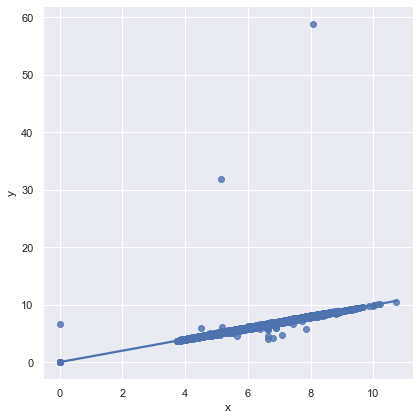

```python
# length vs width
#-----scatter plot--------
sns.set_theme(color_codes=True)
sns.lmplot(x='x', y='y', data=data,height=6)
```

```python
# adding log(y) to check for correlation
data['log(y)'] = np.log1p(data['y'])
```

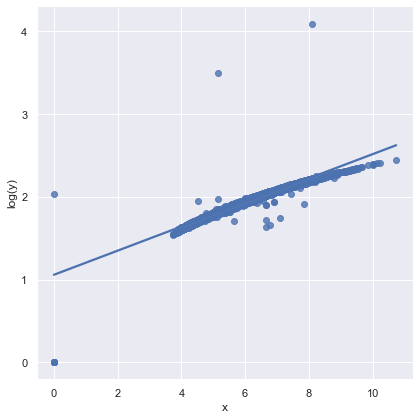

```python
sns.lmplot(x='x', y='log(y)', data=data,height=6)
```

- we can notice that a `linear relationship` exists between the two variables(`y` & `x`)
- The existence of some outliers is also noticeable

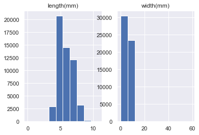

```python
# the distribution of variables
fig,(ax1,ax2) = plt.subplots(1,2)
ax1.hist(data.x)
ax1.set_title('length(mm)')
ax2.hist(data.y)
ax2.set_title('width(mm)')
```

- The `length` feature is close to `Gaussian distribution` whereas the `width` feature is a little `skewed to the right`

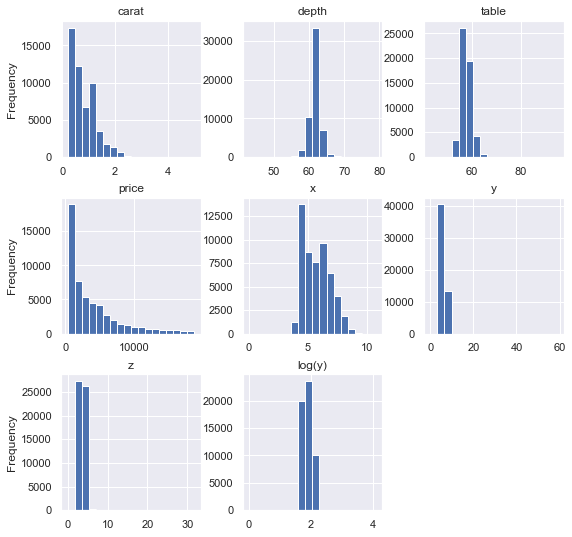

```python
# distribution of each feature
  # get only numerical variables
num_var = data.describe().columns

#plot the histogram of each feature
axList = data[num_var].hist(bins=18,figsize=(9,9))

# Add some x- and y- labels to columns and rows
for ax,title in zip(axList.flatten(),num_var.tolist()):
    ax.set_title(title)
    if ax.get_subplotspec().is_first_col():
        ax.set_ylabel('Frequency')
```

- some features are `skewed` and some of them tend to follow a `Normal Distribution`
- We will perform some `transformations` to some features in order to `reduce the skewness`

# pairplot

- this is a powerful & intuitive plot to summarize the main relationships

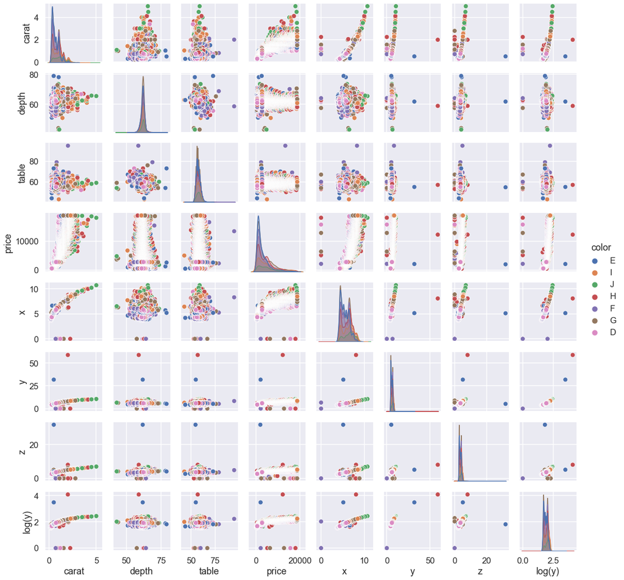

```python
sns.set_context('talk')
sns.pairplot(data, hue='color', height=2)
```

- Using `Polynomial Features` during the `Feature engineering` will help us capture these relationships

```python
# create list of numerical values
l = list(num_var)
```

```python
# remove the log1p(y) added column
l.remove('log(y)')
```

```python
# loop through to create indexes
list_indexes=list()
for i in range(len(l)):
    if(i%2==0 and i!=len(l)-1):
        list_indexes.append((i,i+1))
    if(i==len(l)-1):
        list_indexes.append((i,1))
```

```python
#generate a list of pair indexes
    #check
list_indexes
```

```
[(0, 1), (2, 3), (4, 5), (6, 1)]
```

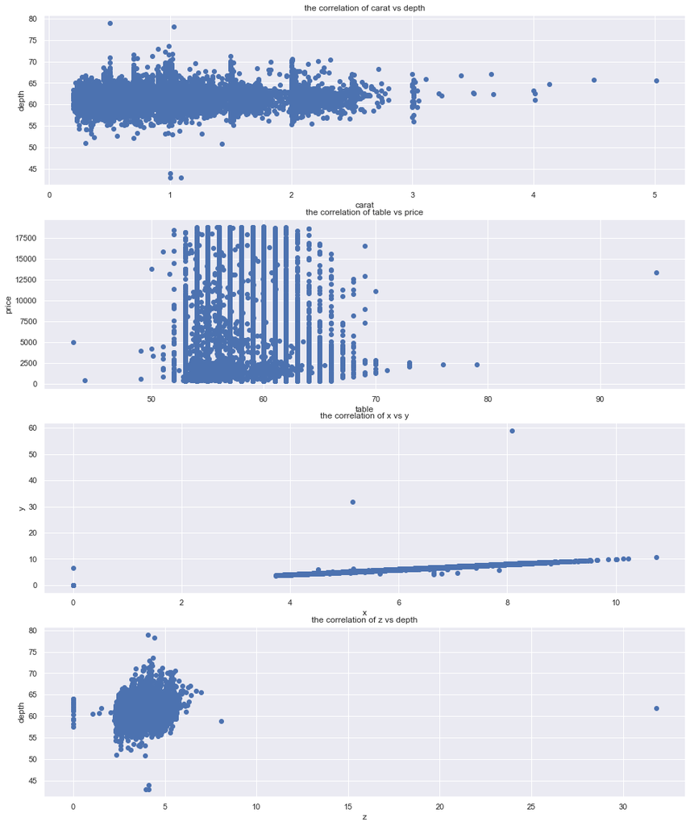

```python
#check for correlation between each two numerical variables
h=1
plt.figure(figsize=(16,20))
for i,j in list_indexes:
    plt.subplot(4, 1, h)
    plt.scatter(data[num_var[i]],data[num_var[j]])
    plt.title(f'the correlation of {num_var[i]} vs {num_var[j]}')
    plt.xlabel(num_var[i])
    plt.ylabel(num_var[j])
    h+=1
plt.show()
```

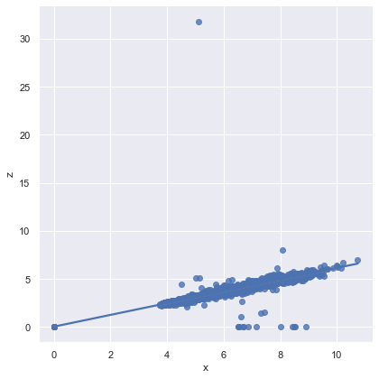

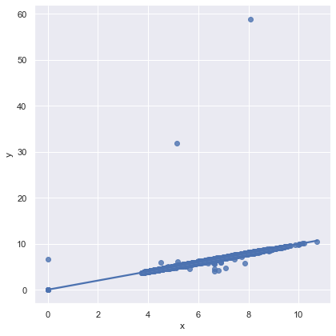

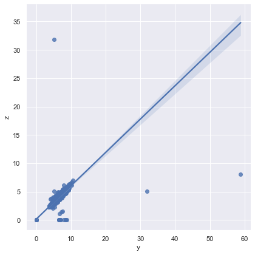

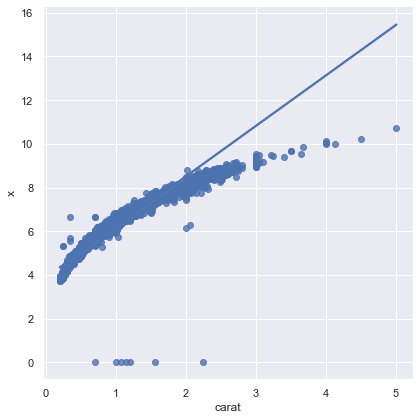

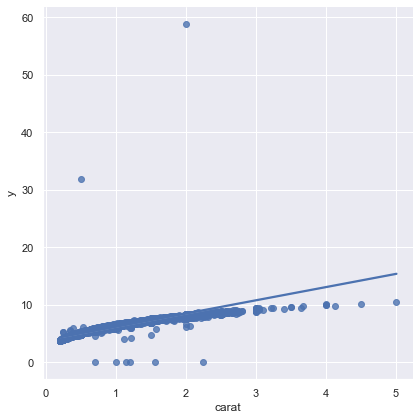

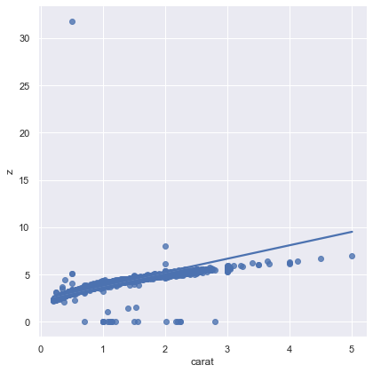

```python
# another powerful plot that builds a linear model
sns.lmplot(x='x', y='z', data=data,height=6)
sns.lmplot(x='x', y='y', data=data,height=6)
sns.lmplot(x='y', y='z', data=data,height=6)
sns.lmplot(x='carat', y='x', data=data,height=6)
sns.lmplot(x='carat', y='y', data=data,height=6)
sns.lmplot(x='carat', y='z', data=data,height=6)
plt.show()
```

the correlation between `x` & `y` is very strong, we notice also the existence of a relationship between `x` & `z`. adding the variable `carat` to the ground brings alot of additional insights

```python
# create a new small dataframe
    # remove the 'log1p(y)' column plus the target variable
small_data = data.drop(['price','log(y)'],axis=1)
```

```python
# remove the "price" column from our list
l.remove('price')
```

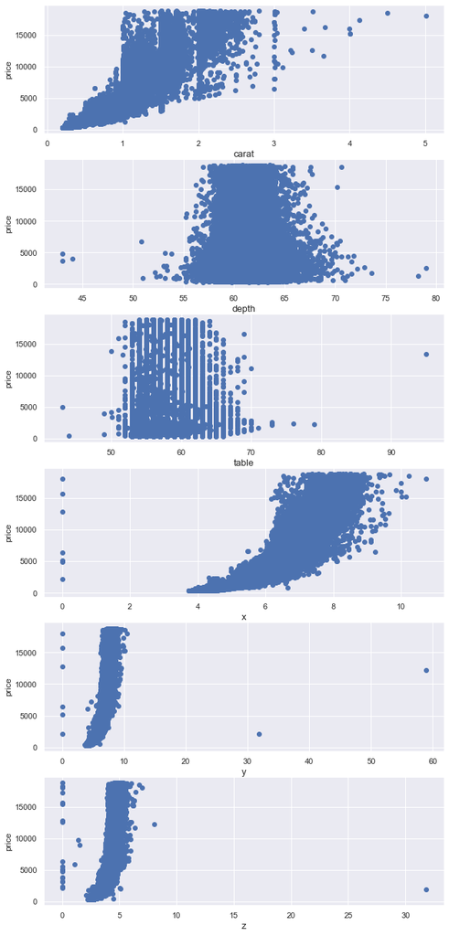

```python
# the correlation of each feature & the target
h=1
plt.figure(figsize=(10,35))
for i in small_data[l]:
    plt.subplot(len(small_data.columns), 1, h)
    h+=1
    plt.scatter(y=data['price'],x=data[i])
    plt.xlabel(i,fontdict={'fontsize':13})
    plt.ylabel('price')
```

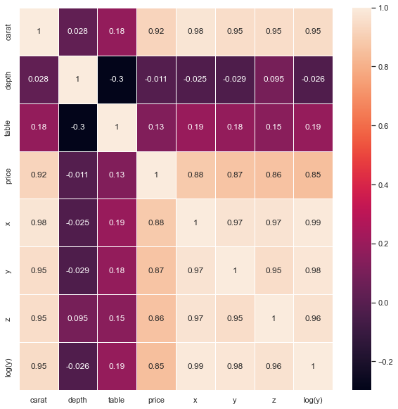

```python
# The correlation matrix(using heatmap)
plt.figure(figsize=(10,10))
    #Generating the correlation matrix
corr = data.corr()
    #heatmap
sns.heatmap(corr,linewidth = 1,annot = True)
```

- As seen before, this heatmap confirms our previous interpretations

```python
# let's create a dataframe of correlations and filter the weak ones
    #Return the indices for the lower-triangle of arr.
trill_indexes = np.tril_indices_from(corr)
corr_array = np.array(corr)

#make the unused values NANs
corr_array[trill_indexes] = np.nan
```

```python
# preview result to understand
pd.DataFrame(corr_array)
```

|  | 0 | 1 | 2 | 3 | 4 | 5 | 6 | 7 |
| --- | --- | --- | --- | --- | --- | --- | --- | --- |
| 0 | NaN | 0.027861 | 0.181091 | 0.921548 | 0.975380 | 0.951908 | 0.953542 | 0.947523 |
| 1 | NaN | NaN | -0.297669 | -0.011048 | -0.025348 | -0.029389 | 0.094757 | -0.026035 |
| 2 | NaN | NaN | NaN | 0.126566 | 0.194855 | 0.183231 | 0.150270 | 0.187081 |
| 3 | NaN | NaN | NaN | NaN | 0.884504 | 0.865395 | 0.861208 | 0.852543 |
| 4 | NaN | NaN | NaN | NaN | NaN | 0.974592 | 0.970686 | 0.990493 |
| 5 | NaN | NaN | NaN | NaN | NaN | NaN | 0.951844 | 0.982435 |
| 6 | NaN | NaN | NaN | NaN | NaN | NaN | NaN | 0.964685 |
| 7 | NaN | NaN | NaN | NaN | NaN | NaN | NaN | NaN |

```python
# create our correlation dataframe
corr_values = pd.DataFrame(corr_array, columns=corr.columns , index = corr.index)
```

```python
corr_values
```

|  | carat | depth | table | price | x | y | z | log(y) |
| --- | --- | --- | --- | --- | --- | --- | --- | --- |
| carat | NaN | 0.027861 | 0.181091 | 0.921548 | 0.975380 | 0.951908 | 0.953542 | 0.947523 |
| depth | NaN | NaN | -0.297669 | -0.011048 | -0.025348 | -0.029389 | 0.094757 | -0.026035 |
| table | NaN | NaN | NaN | 0.126566 | 0.194855 | 0.183231 | 0.150270 | 0.187081 |
| price | NaN | NaN | NaN | NaN | 0.884504 | 0.865395 | 0.861208 | 0.852543 |
| x | NaN | NaN | NaN | NaN | NaN | 0.974592 | 0.970686 | 0.990493 |
| y | NaN | NaN | NaN | NaN | NaN | NaN | 0.951844 | 0.982435 |
| z | NaN | NaN | NaN | NaN | NaN | NaN | NaN | 0.964685 |
| log(y) | NaN | NaN | NaN | NaN | NaN | NaN | NaN | NaN |

```python
# stack the dataframe to ensure data readability
corr_values = (
    corr_values
    .stack()
    .to_frame()
    .reset_index()
    .rename(columns={
        'level_0' : 'feature 1',
        'level_1' : 'feature 2',
        0 : 'correlation'
    })

)
```

```python
# get the absolute value of correlations for sorting
corr_values['abs correlation'] = corr_values.correlation.abs()
```

```python
# sort by 'abs correlation' following a descending order
corr_values.sort_values(by='abs correlation',ascending=False)
```

|  | feature 1 | feature 2 | correlation | abs correlation |
| --- | --- | --- | --- | --- |
| 24 | x | log(y) | 0.990493 | 0.990493 |
| 26 | y | log(y) | 0.982435 | 0.982435 |
| 3 | carat | x | 0.975380 | 0.975380 |
| 22 | x | y | 0.974592 | 0.974592 |
| 23 | x | z | 0.970686 | 0.970686 |
| 27 | z | log(y) | 0.964685 | 0.964685 |
| 5 | carat | z | 0.953542 | 0.953542 |
| 4 | carat | y | 0.951908 | 0.951908 |
| 25 | y | z | 0.951844 | 0.951844 |
| 6 | carat | log(y) | 0.947523 | 0.947523 |
| 2 | carat | price | 0.921548 | 0.921548 |
| 18 | price | x | 0.884504 | 0.884504 |
| 19 | price | y | 0.865395 | 0.865395 |
| 20 | price | z | 0.861208 | 0.861208 |
| 21 | price | log(y) | 0.852543 | 0.852543 |
| 7 | depth | table | -0.297669 | 0.297669 |
| 14 | table | x | 0.194855 | 0.194855 |
| 17 | table | log(y) | 0.187081 | 0.187081 |
| 15 | table | y | 0.183231 | 0.183231 |
| 1 | carat | table | 0.181091 | 0.181091 |
| 16 | table | z | 0.150270 | 0.150270 |
| 13 | table | price | 0.126566 | 0.126566 |
| 11 | depth | z | 0.094757 | 0.094757 |
| 10 | depth | y | -0.029389 | 0.029389 |
| 0 | carat | depth | 0.027861 | 0.027861 |
| 12 | depth | log(y) | -0.026035 | 0.026035 |
| 9 | depth | x | -0.025348 | 0.025348 |
| 8 | depth | price | -0.011048 | 0.011048 |

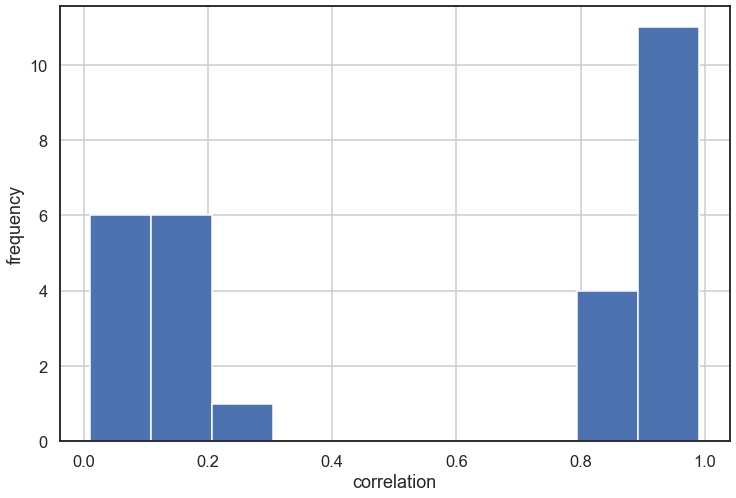

```python
# plot to see correlation scores
sns.set_context('talk')
sns.set_style('white')
corr_values['abs correlation'].hist(figsize=(12,8))
plt.xlabel('correlation')
plt.ylabel('frequency')
```

- we notice that the frequency of a correlation score ~ .9 is high

##### Data Preprocessing part

```python
# Encode categorical variables(since there is an order, we'll use ordianl encoder to let our ML model understand the order)
from sklearn.preprocessing import OrdinalEncoder
```

```python
# keep a copy of data intact
copy_data = data.copy()
```

```python
# filter numerical values
categories = data.dtypes[data.dtypes == 'object'].to_frame().index
```

```python
# preview
categories
```

```
Index(['cut', 'color', 'clarity'], dtype='object')
```

```python
# we well prepare lists of different values for each categorical variable(ordered)
ord_color = ['J','I','H','G','F','E','D']
ord_cut = data['cut'].value_counts().sort_values().index.tolist()
ord_clarity = ['I1', 'SI2', 'SI1', 'VS2', 'VS1', 'VVS2', 'VVS1', 'IF']
```

```python
# add lists to a dictionary
ordered = {
    'color':ord_color,
    'cut':ord_cut,
    'clarity':ord_clarity
}
```

```python
data['color']
```

```
0        E
1        E
2        E
3        I
4        J
        ..
53935    D
53936    D
53937    D
53938    H
53939    D
Name: color, Length: 53794, dtype: object
```

```python
# encode categories using Ordinale encoder
# perform encoding
for category in categories:
    oec = OrdinalEncoder(categories=[ordered[category]])
    data[category] = oec.fit_transform(data[[category]])
```

```python
# verify
print('before')
print(copy_data[categories])
print('-'*20)
print('after')
print(data[categories])
```

```
before
             cut color clarity
0          Ideal     E     SI2
1        Premium     E     SI1
2           Good     E     VS1
3        Premium     I     VS2
4           Good     J     SI2
...          ...   ...     ...
53935      Ideal     D     SI1
53936       Good     D     SI1
53937  Very Good     D     SI1
53938    Premium     H     SI2
53939      Ideal     D     SI2

[53794 rows x 3 columns]
```

[output cut: 16 more lines]

- Now we have an `all-numerical` data

##### Outliers

- handling outliers(Outliers are the values that look different from the other values in the data)

###### Why dealing with outliers ?

- Outliers in the data may causes problems during model fitting (esp. linear models).
- Outliers may inflate the error metrics which give higher weights to large errors (example, mean squared error, RMSE).

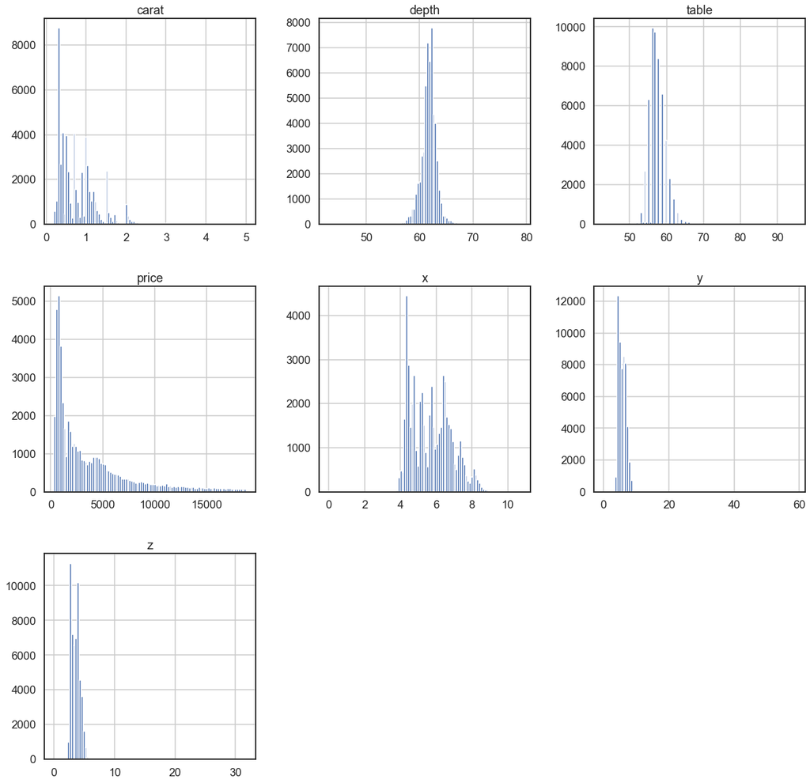

```python
# check for outliers
    #via histograms
axList = data[num_var].drop('log(y)',axis=1).hist(bins=100, figsize=(20,20))
```

[output not shown]

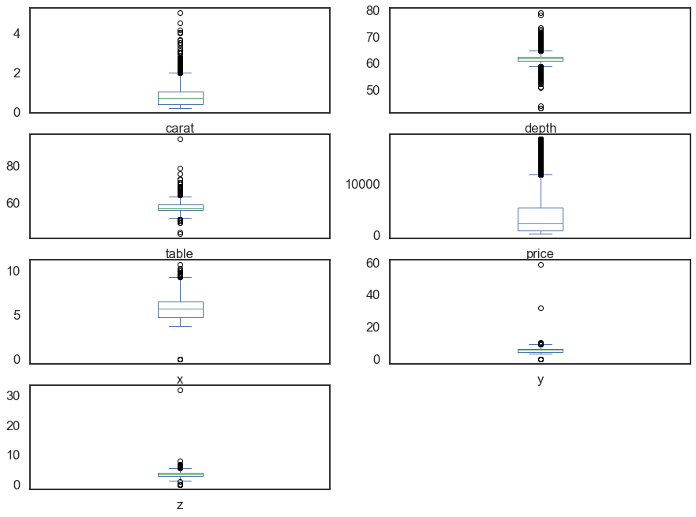

```python
    # via boxplots
data[num_var].drop('log(y)',axis=1).plot(kind="box",subplots=True,layout=(7,2),figsize=(15,20))
```

- The existence of outliers is noticeable through box-plots
- Visualy, we can't detect outliers correctly(case of histograms) thus let's move to the statistical part